# Analyzing Climate Change Impact on Vegetation Dynamics in the Four Corners Region

```python
import pandas as pd
import matplotlib.pyplot as plt
import seaborn as sns
```

Climate change brings significant challenges to ecosystems all over the world, where the behavior of vegetation is a key indicator of ecological sustainability. This data visualization project shows the impact of climate factors on vegetation cover within the Four Corners region.

## Loading the Data

The data utilized in this project:

- Climate and Drought Data from NOAA provides important information on temperature, precipitation, and other climate variables.
- Vegetation Cover Data from USGS gathers vegetation cover with geographic and temporal variables, giving information about the ecological nature of the NBNM region.

```python
nearterm = pd.read_csv('data/nearterm_data_2020-2024.csv')
historic = pd.read_csv('data/NABR_historic.csv')
```

```python
nearterm.head()
historic.head()
```

|  | long | lat | year | TimePeriod | RCP | scenario | treecanopy | Ann_Herb | Bare | Herb | ... | PPT_Annual | T_Winter | T_Summer | T_Annual | Tmax_Summer | Tmin_Winter | VWC_Winter_whole | VWC_Spring_whole | VWC_Summer_whole | VWC_Fall_whole |
| --- | --- | --- | --- | --- | --- | --- | --- | --- | --- | --- | --- | --- | --- | --- | --- | --- | --- | --- | --- | --- | --- |
| 0 | -110.0472 | 37.60413 | 1980 | Hist | historical | sc1 | 0 | 0 | 84 | 5 | ... | 13.79 | 0.964835 | 23.15924 | 23.159240 | 37.05 | NaN | NaN | NaN | NaN | NaN |
| 1 | -110.0472 | 37.60413 | 1980 | Hist | historical | sc1 | 0 | 0 | 84 | 5 | ... | 2.69 | 0.964835 | 23.15924 | 0.964835 | 37.05 | NaN | NaN | NaN | NaN | NaN |
| 2 | -110.0472 | 37.60413 | 1980 | Hist | historical | sc1 | 0 | 0 | 84 | 5 | ... | 13.79 | 0.964835 | 23.15924 | 0.964835 | 37.05 | NaN | NaN | NaN | NaN | NaN |
| 3 | -110.0472 | 37.60413 | 1980 | Hist | historical | sc1 | 0 | 0 | 84 | 5 | ... | 2.69 | 0.964835 | 23.15924 | 23.159240 | 37.05 | NaN | NaN | NaN | NaN | NaN |
| 4 | -110.0472 | 37.60413 | 1980 | Hist | historical | sc1 | 0 | 0 | 84 | 5 | ... | NaN | NaN | NaN | NaN | NaN | -12.45 | 0.113447 | 0.096831 | 0.041876 | 0.052298 |

5 rows × 29 columns

## Data Cleaning

```python
print(nearterm.isnull().sum())
print(historic.isnull().sum())
```

```
long                                          0
lat                                           0
year                                          0
TimePeriod                                    0
RCP                                           0
scenario                                      0
treecanopy                                    0
Ann_Herb                                      0
Bare                                          0
Herb                                          0
Litter                                        0
Shrub                                         0
DrySoilDays_Summer_whole                  37529
Evap_Summer                               37529
ExtremeShortTermDryStress_Summer_whole    37535
FrostDays_Winter                          37529
NonDrySWA_Summer_whole                    37630
PPT_Winter                                17920
PPT_Summer                                17920
PPT_Annual                                23802
T_Winter                                  17920
T_Summer                                  17920
T_Annual                                  23802
Tmax_Summer                               17920
Tmin_Winter                               37529
VWC_Winter_whole                          37529
VWC_Spring_whole                          37529
VWC_Summer_whole                          37529
VWC_Fall_whole                            37529
dtype: int64
long                                         0
lat                                          0
year                                         0
TimePeriod                                   0
RCP                                          0
scenario                                     0
treecanopy                                   0
Ann_Herb                                     0
Bare                                         0
Herb                                         0
Litter                                       0
Shrub                                        0
DrySoilDays_Summer_whole                  9345
Evap_Summer                               9345
ExtremeShortTermDryStress_Summer_whole    9345
FrostDays_Winter                          9345
NonDrySWA_Summer_whole                    9368
PPT_Winter                                4368
PPT_Summer                                4368
PPT_Annual                                5891
T_Winter                                  4368
T_Summer                                  4368
T_Annual                                  5891
Tmax_Summer                               4368
Tmin_Winter                               9345
VWC_Winter_whole                          9345
VWC_Spring_whole                          9345
VWC_Summer_whole                          9345
VWC_Fall_whole                            9345
dtype: int64
```

Since there was a significant amount of missing data in both datasets, the columns consisting of more than 50% of missing data were dropped. For columns with 50% or less missing values, the missing data was imputed based on the column’s median value. The rows with missing data after these processes were then dropped to result in the cleaned datasets ready for analysis.

```python
nearterm_missing = nearterm.isna().mean().round(4) * 100
historic_missing = historic.isna().mean().round(4) * 100

print(nearterm_missing)
print(historic_missing)

t = 0.5

nearterm_cleaned = nearterm.loc[:, nearterm.isna().mean() < t]
historic_cleaned = historic.loc[:, historic.isna().mean() < t]

nearterm_cleaned.fillna(nearterm_cleaned.median(), inplace=True)
historic_cleaned.fillna(historic_cleaned.median(), inplace=True)

nearterm_cleaned.dropna(inplace=True)
historic_cleaned.dropna(inplace=True)

print(nearterm_cleaned.isna().sum())
print(historic_cleaned.isna().sum())
```

```
long                                       0.00
lat                                        0.00
year                                       0.00
TimePeriod                                 0.00
RCP                                        0.00
scenario                                   0.00
treecanopy                                 0.00
Ann_Herb                                   0.00
Bare                                       0.00
Herb                                       0.00
Litter                                     0.00
Shrub                                      0.00
DrySoilDays_Summer_whole                  67.25
Evap_Summer                               67.25
ExtremeShortTermDryStress_Summer_whole    67.26
FrostDays_Winter                          67.25
NonDrySWA_Summer_whole                    67.43
PPT_Winter                                32.11
PPT_Summer                                32.11
PPT_Annual                                42.65
T_Winter                                  32.11
T_Summer                                  32.11
T_Annual                                  42.65
Tmax_Summer                               32.11
Tmin_Winter                               67.25
VWC_Winter_whole                          67.25
VWC_Spring_whole                          67.25
VWC_Summer_whole                          67.25
VWC_Fall_whole                            67.25
dtype: float64
long                                       0.00
lat                                        0.00
year                                       0.00
TimePeriod                                 0.00
RCP                                        0.00
scenario                                   0.00
treecanopy                                 0.00
Ann_Herb                                   0.00
Bare                                       0.00
Herb                                       0.00
```

[output cut: 45 more lines]

```
scenario       0
treecanopy     0
Ann_Herb       0
Bare           0
Herb           0
Litter         0
Shrub          0
PPT_Winter     0
PPT_Summer     0
PPT_Annual     0
T_Winter       0
T_Summer       0
T_Annual       0
Tmax_Summer    0
dtype: int64
```

[output not shown]

## Exploratory Data Analysis

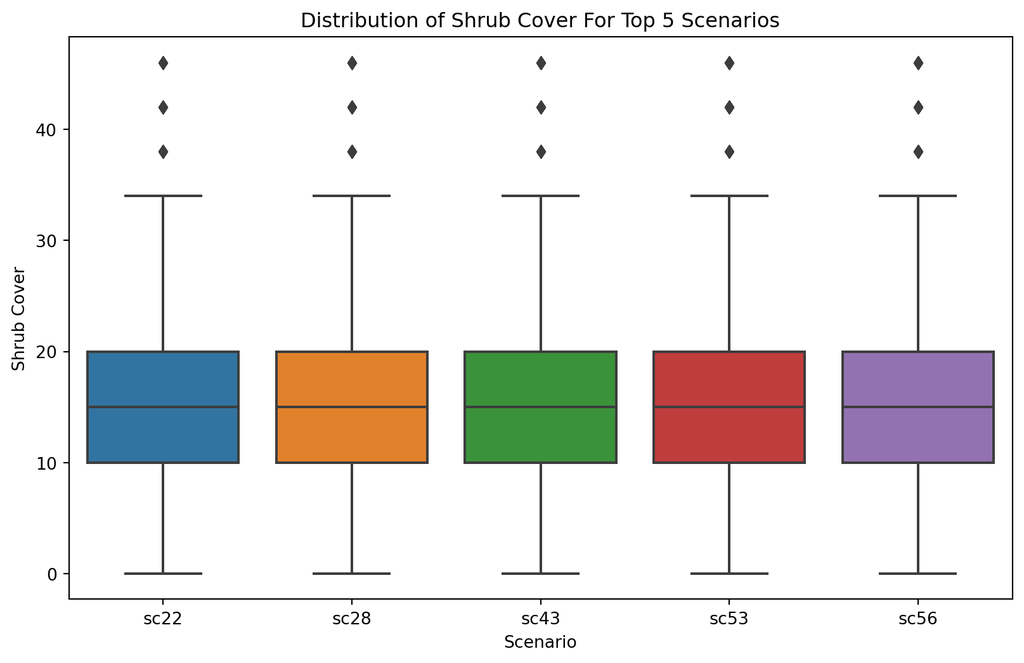

```python
scenario_means = nearterm_cleaned.groupby('scenario')['Shrub'].mean().sort_values(ascending=False)
top_scenarios_5 = scenario_means.head(5).index
top_scenarios = nearterm_cleaned[nearterm_cleaned['scenario'].isin(top_scenarios_5)]


plt.figure(figsize=(10, 6))
sns.boxplot(data=top_scenarios, x='scenario', y='Shrub')
plt.title('Distribution of Shrub Cover For Top 5 Scenarios')
plt.xlabel('Scenario')
plt.ylabel('Shrub Cover')
plt.show()
```

In order to understand whether precipitation influences vegetation, the relationship between tree canopy cover and annual precipitation was visualized below.

```
No artists with labels found to put in legend.  Note that artists whose label start with an underscore are ignored when legend() is called with no argument.
```

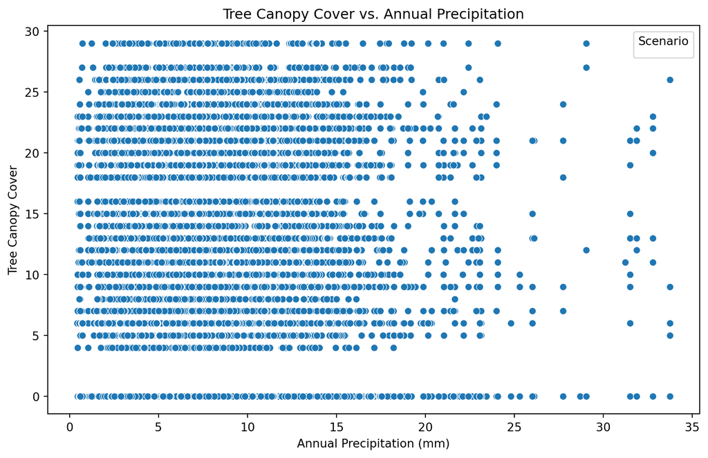

```python
plt.figure(figsize=(10, 6))
sns.scatterplot(data=nearterm_cleaned, x='PPT_Annual', y='treecanopy')
plt.title('Tree Canopy Cover vs. Annual Precipitation')
plt.xlabel('Annual Precipitation (mm)')
plt.ylabel('Tree Canopy Cover')
plt.legend(title='Scenario')
plt.show()
```

There appears to be no relationship between the two variables as the points are randomly scattered in the plot.

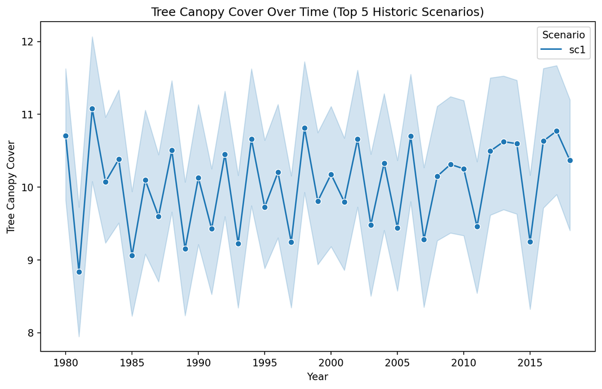

```python
historic_scenario_means = historic_cleaned.groupby('scenario')['treecanopy'].mean().sort_values(ascending=False)
historic_top_scenarios_5 = historic_scenario_means.head(5).index
historic_top_scenarios = historic_cleaned[historic_cleaned['scenario'].isin(historic_top_scenarios_5)]

plt.figure(figsize=(10, 6))
sns.lineplot(data=historic_top_scenarios, x='year', y='treecanopy', hue='scenario', marker='o')
plt.title('Tree Canopy Cover Over Time (Top 5 Historic Scenarios)')
plt.xlabel('Year')
plt.ylabel('Tree Canopy Cover')
plt.legend(title='Scenario')
plt.show()
```

The earlier years appear to have the most variability in the flucutations in the values between each year, but the sharp increases and decreases in the values are close to being constant.

These visuals show a broad understanding of the data.

## Interactive Visuals

```python
import plotly.graph_objects as go

scenario_means = nearterm_cleaned.groupby('scenario')['treecanopy'].mean().sort_values(ascending=False)
top_scenarios_5 = scenario_means.head(5).index
top_scenarios = nearterm_cleaned[nearterm_cleaned['scenario'].isin(top_scenarios_5)]

fig = go.Figure()

for scenario in top_scenarios_5:
    df = top_scenarios[top_scenarios['scenario'] == scenario]
    fig.add_trace(go.Histogram(x=df['PPT_Annual'], name=scenario, opacity=0.75))

fig.update_layout(
    title='Distribution of Annual Precipitation by Top 5 Scenario Based on Average Tree Canopy Cover',
    xaxis_title='Annual Precipitation (mm)',
    yaxis_title='Count',
    legend_title='Scenario',
    barmode='overlay'
)
fig.show()
```

[interactive chart not shown]

They appear to be roughly distributed similarily.

```python
seasons = nearterm_cleaned['TimePeriod'].unique()

fig = go.Figure()

for season in seasons:
    season_data = nearterm_cleaned[nearterm_cleaned['TimePeriod'] == season]
    fig.add_trace(go.Scatter(x=season_data['year'], y=season_data['treecanopy'], mode='lines+markers', name=season))

fig.update_layout(
    title='Tree Canopy Cover by Season',
    xaxis_title='Year',
    yaxis_title='Tree Canopy Cover',
    legend_title='Season'
)

fig.show()
```

[interactive chart not shown]

There is a lot of variability over time.